# ESM 206 Lab 5

Kate Shoemaker

10/29/2019

#### Lab 5 Objectives

- Learn to parse dates with ‘lubridate’ package
- Get counts of observationswith count()
- Uncount() rows
- One and two-sample t-test
- Create a heatmap with geom_tile()

Use the tidyr::uncount() function to convert our lobster data from frequency format to case format (every observation has its own row)

```r
lobster_tidy <- lobster_abundance %>%
  tidyr::uncount(lobster_count)
```

put variable column that has the observation: this row will be repeated in every other column and that column will go away. Every individual lobster has its own row now. In tidy format. Important for raw data, helps get from frequency to case format.

#### Exploratory data visualization

We’re only going to consider ‘site’ as our varible of interest

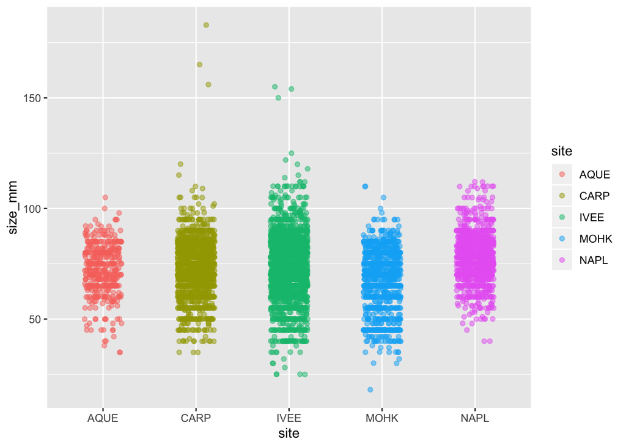

```r
ggplot(lobster_tidy, aes(x = site, y = size_mm)) +
  geom_jitter(aes(color = site),
              alpha = 0.5,
              width = 0.2)
```

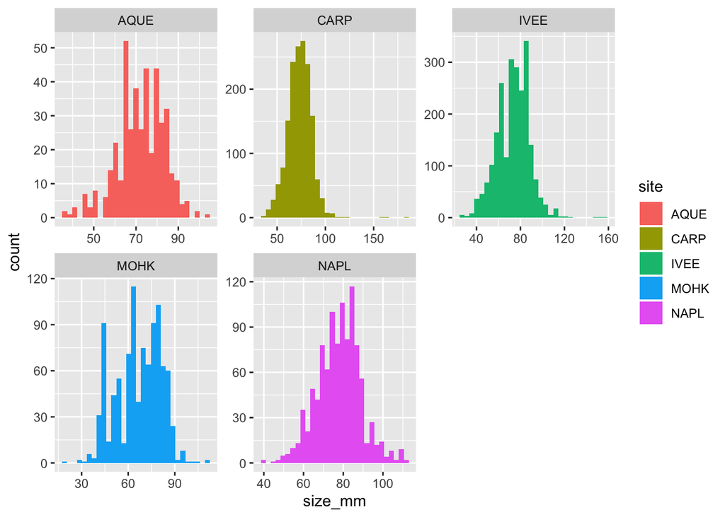

```r
# Histogram

ggplot(lobster_tidy, aes(x = size_mm)) +
  geom_histogram(aes(fill = site)) +
  facet_wrap(~site, scales = "free")
```

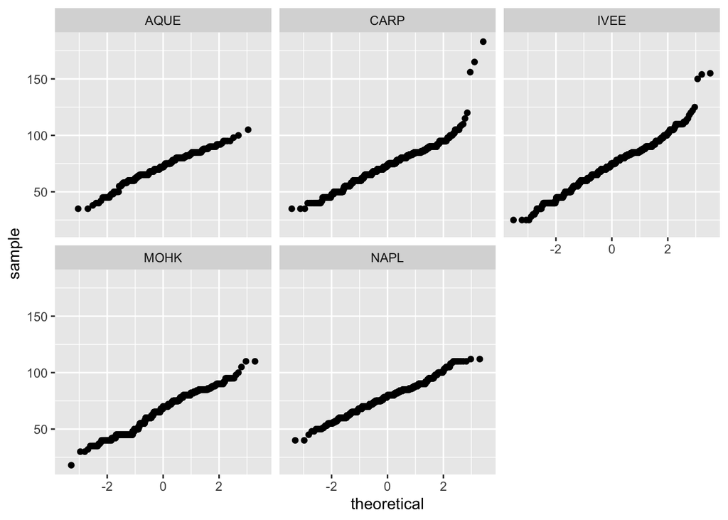

```r
# Quantile- Quantile

ggplot(lobster_tidy,aes(sample = size_mm)) +
  geom_qq() +
  facet_wrap(~site)
```

####Notes scales = “free” allow each scale to fit the data. Default is all the saem

default geom_qq is noraml distribution if you get a linear relationship, that indicates a normal distribution. Don’t let outliers lead you to believe you don’t have normal distribution. Even if actual samples didn’t look normal distributed, doesn’t indicated means couldnt be normally distributed. When you plot all the means, they will be normally distributed (CLT) especially as sample sie gets larger. Doesn’t matter what underlying population looks like.

#### Convert the date column to class ‘Date’

We’ll use the lubridate package to convert to date format and then to help us easily parce month and year

```r
lobster_date <- lobster_tidy %>%
  mutate(
    date_new = lubridate::mdy(date)
  )
```

give it exisiting set up and column name that currenty exists. this puts it in YYYY-MM-DD

Now let’s parce year and month using lubridate::month() and lubridate::year():

```r
lobster_parce_date <- lobster_date %>%
  mutate(
    obs_month = lubridate::month(date_new, label = TRUE),
    obs_year = lubridate::year(date_new)
  )
```

lubridate was built to work with dates and times. Excel messes this up a lot.

Now let’s find counts of observed lobsters based on different hierarcial groupings:

count() groups things based on how you tell it to group it

First let’s count lobsters by year and month

```r
lobster_ym <- lobster_parce_date %>%
  dplyr::count(obs_year, obs_month)

lobster_ym
```

```
## # A tibble: 8 x 3
##   obs_year obs_month     n
##      <dbl> <ord>     <int>
## 1     2012 Aug         231
## 2     2013 Aug         243
## 3     2014 Aug         404
## 4     2014 Sep         106
## 5     2015 Aug        1100
## 6     2016 Aug         809
## 7     2017 Aug        1668
## 8     2018 Aug        1805
```

```r
lobster_y <- lobster_parce_date %>%
  dplyr::count(obs_year)

lobster_site <- lobster_parce_date %>%
  dplyr::count(site)

lobster_site
```

```
## # A tibble: 5 x 2
##   site      n
##   <chr> <int>
## 1 AQUE    422
## 2 CARP   1619
## 3 IVEE   2304
## 4 MOHK    982
## 5 NAPL   1039
```

If we want to craete a summary table that contains statistics other than counts by group, it’s easier to use group_by() + n()

```r
lobster_summary <- lobster_parce_date %>%
  group_by(site) %>%
  summarize(
    mean_size = mean(size_mm, na.rm = TRUE),
    sd_size = sd(size_mm, na.rm = TRUE),
    lobster_number = n()
  )
lobster_summary
```

```
## # A tibble: 5 x 4
##   site  mean_size sd_size lobster_number
##   <chr>     <dbl>   <dbl>          <int>
## 1 AQUE       72.3    11.4            422
## 2 CARP       72.8    12.5           1619
## 3 IVEE       73.6    14.4           2304
## 4 MOHK       66.9    14.2            982
## 5 NAPL       78.2    11.1           1039
```

If you’re just doing counts by group, use counts. But if your’re doing more summary stats, use group_by and summarize.

#### Find confidence intervals

Use t.test() function to find confidence intervals for one sample and perform t-tests to compare means of two samples

```r
ivee_lobster <- lobster_tidy %>%
  filter(site == "IVEE") %>%
  pull(size_mm)

t.test(ivee_lobster)
```

```
##
##  One Sample t-test
##
## data:  ivee_lobster
## t = 245.23, df = 2302, p-value < 2.2e-16
## alternative hypothesis: true mean is not equal to 0
## 95 percent confidence interval:
##  72.99130 74.16806
## sample estimates:
## mean of x
##  73.57968
```

#### Two-sample t-test to compare means

were asking, “Do i think i have enough evidence to show that two samples that are drawn have different means” are my means so different that I think ihave sufficient evidence to conclude that I have means from different pops

We want to ask, is there significant difference in lobster length at Naples and Mohawk reefs?

We’ve done our necessary exploratory analyses to determine that a two-sample t-test for means comparison is appropriate.

```r
napl_sample <- lobster_tidy %>%
  filter(site == "NAPL") %>%
  pull(size_mm)

mohk_sample <- lobster_tidy %>%
  filter(site == "MOHK") %>%
  pull(size_mm)

mn_ttest <- t.test(mohk_sample, napl_sample)
mn_ttest
```

```
##
##  Welch Two Sample t-test
##
## data:  mohk_sample and napl_sample
## t = -19.849, df = 1850.8, p-value < 2.2e-16
## alternative hypothesis: true difference in means is not equal to 0
## 95 percent confidence interval:
##  -12.43436 -10.19806
## sample estimates:
## mean of x mean of y
##  66.86833  78.18454
```

have to give a t-test an entire vector of observations cant just give it mean. this is a 95% confidence interval that explains difference in means

```r
lobster_mn <- lobster_tidy %>%
  filter(site %in% c("NAPL", "MOHK"))


mn_ttest2 <- t.test(size_mm ~ site, data = lobster_mn)
mn_ttest2
```

```
##
##  Welch Two Sample t-test
##
## data:  size_mm by site
## t = -19.849, df = 1850.8, p-value < 2.2e-16
## alternative hypothesis: true difference in means is not equal to 0
## 95 percent confidence interval:
##  -12.43436 -10.19806
## sample estimates:
## mean in group MOHK mean in group NAPL
##           66.86833           78.18454
```

```r
mn_ttest2$p.value
```

```
## [1] 1.215408e-79
```

```r
mn_ttest2$statistic
```

```
##         t
## -19.84873
```

same results as separated vector form but just using model form now.

Here is the p-value: 1.215407810^{-79} Here is the t-statistic: -19.8487322

This allows you to not just copy and paste you values- helps reproducibility

#### Now a heatmap! (good way to show three variables)

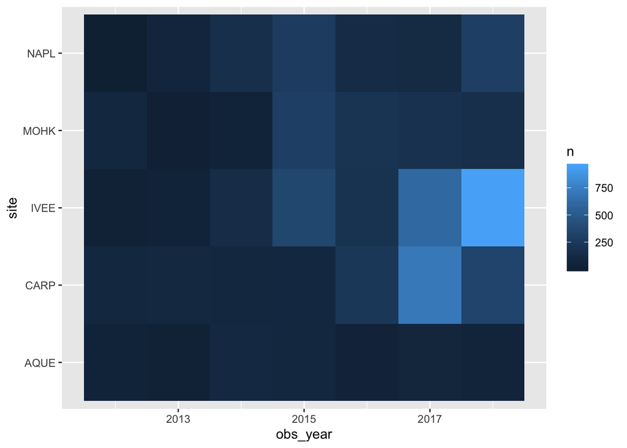

```r
lobster_ys <- lobster_parce_date %>%
  count(obs_year, site)

ggplot(data = lobster_ys, aes(x = obs_year, y = site)) +
  geom_tile(aes(fill = n))
```